# Modeling and Simulation

## Discrete Population growth

### Geometric growth

Growth and reproduction—and the limits placed thereon by available food sources—were subject of one of the earliest quantitative models in biology (by Malthus in 1798):

$$\label{eq:geometric-growth}
n(t+1) = r n(t)$$

Eq [eq:geometric-growth], which defines so-called *geometric growth*, says that the population at time $t+1$ is simply a multiple $r$ of the population at time $t$. Its solution is

$$\label{eq:geometric}
n(t) = r^t n_0$$

where $n_0$ is the population at time $t=0$.

This is a good time to introduce `ggplot`, a popular data visualization package in R. First let’s set up some data to visualize:

```r
t = 0:10  ## equivalent to t = c(0, 1, 2, 3, 4, 5, 6, 7, 8, 10)
growthData = data.frame(t=t, n=2^t)
growthData
```

```
##     t    n
## 1   0    1
## 2   1    2
## 3   2    4
## 4   3    8
## 5   4   16
## 6   5   32
## 7   6   64
## 8   7  128
## 9   8  256
## 10  9  512
## 11 10 1024
```

I want to emphasize a couple of points here: 1. When creating `growthData`, we use `t` as both a column name in the `data.frame`—when it shows up on the left-hand side of the equals sign of `t=t`—as well as as the variable `t`. - The variable `t` in fact shows up twice: once in the right-hand side of `t=t` and once in the right hand side of `n=2^t`.

2. Just as with the other binary operators discussed in section 1.9, the binary operator `^` works elementwise on its second argument (the vector `t`),
   - though here we supplied only a single number (`2`) as its first argument: this number is *recycled* to be used with each element of `t`.

Now, on to plotting!

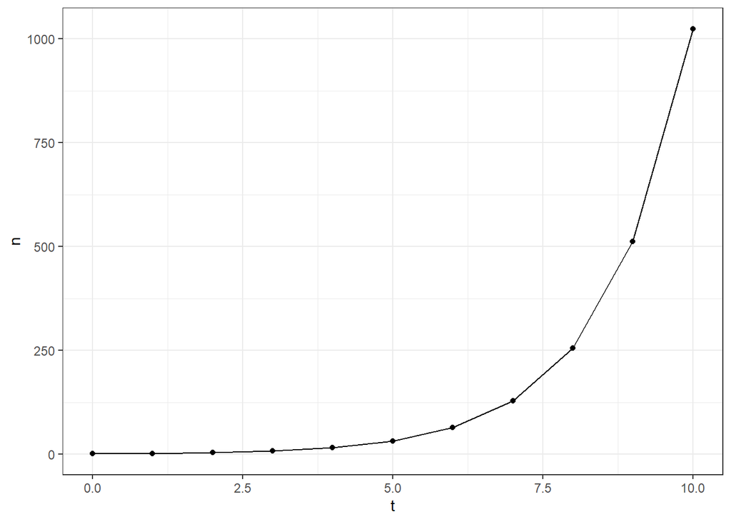

```r
## install.packages("ggplot2")  ## uncomment and run if necessary
library(ggplot2)
theme_set(theme_bw())  ## tell ggplot to use white background
gg = ggplot(
    growthData,    ## first argument is data.frame to draw from
    aes(x=t, y=n)  ## aes function maps x, y positions to column names
)
gg = gg + geom_point()   ## add points to plot
gg = gg + geom_line()  ## add lines connecting points
print(gg)
```

Note that `ggplot` builds up an R object—I named it `gg`—representing the plot which must specify the data set (contained in a `data.frame` object) to be visualized, the “mapping” (specified using `aes`) between things like x- and y-positions in the plot and the column names of the data set, and finally the `geom`etric objects (points, lines, etc.) to include in the plot. This building up is done using the `+` binary operator; remember that such operators are really just R functions with two arguments and can work differently depending on what types of objects are passed into them as arguments!

### The logistic map

The rapid growth implied by Eq [eq:geometric] (as shown in the plot above) is not generally sustainable in a world of limited resources, however. As $n$ grows over time, at some point the rate of increase must slow down. There are many ways in which this might happen, but one simple modification to the geometric model that incorporates such effects is the *logistic map*:

$$\label{eq:logistic-map}
n(t+1) = r n(t) \left( 1-\frac{n(t)}{k} \right)$$

Eq [eq:logistic-map] modifies Eq [eq:geometric-growth] by multiplying by $(1-n(t)/k)$. This factor is approximately 1 for $n(t) \ll k$, so that growth looks geometric starting from very small numbers, but then slows down such that if

$$\label{eq:logistic-map-fixed-point}
n(t) = \frac{k (r-1)}{r} = n_{\text{*}}$$

then $n(t+1)$ will also be equal to $n_{\text{*}}$, that is, there will be no continued growth at all! For $n(t) > n_{\text{*}}$, you will in fact obtain $n(t+1) < n(t)$; that is, the population shrinks instead of growing.

We can simplify Eq [eq:logistic-map] a bit by *nondimensionalizing* it as follows: Define

$$\label{eq:nondimensionalize-n-to-x}
x(t) = \frac{n(t)}{k}$$

so that, dividing both sides of Eq [eq:logistic-map] by $k$, we obtain:

$$\label{eq:nondimensionalized-logistic-map}
x(t+1) = r x(t) \left( 1 - x(t) \right)$$

The nontrivial steady state value of $x$ is then

$$\label{eq:nondimensionalized-fixed-point}
x_{\text{*}} = \frac{r-1}{r}$$

What does population growth under the logistic map look like? Let’s define a function

```r
logisticMapTrajectory = function(r, x0, tmax) {
    x = rep(x0, tmax+1)
     ## note: above sets all (tmax+1) elements of vector x to x0;
     ## these values will be replaced below with correct values
    for (t in 1:tmax) {
        x[[t+1]] = r * x[[t]] * (1-x[[t]])
    }
    return(data.frame(
        t = 0:tmax,
        x = x,
        r = r  ## keep track of which r value was used:
               ## r is recycled tmax+1 times here!
    ))
}
```

which we can use to plot trajectories:

```r
traj_r2 = logisticMapTrajectory(r=2, x0=0.01, tmax=15)
head(traj_r2)
```

```
##   t          x r
## 1 0 0.01000000 2
## 2 1 0.01980000 2
## 3 2 0.03881592 2
## 4 3 0.07461849 2
## 5 4 0.13810114 2
## 6 5 0.23805843 2
```

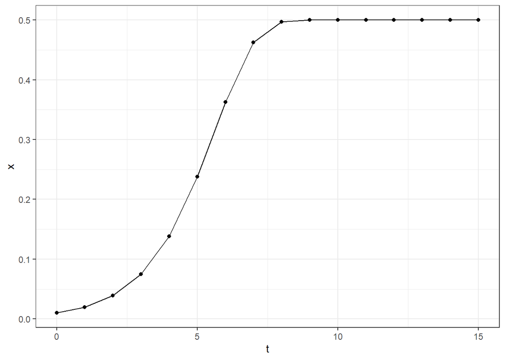

```r
gg = ggplot(
    traj_r2,       ## traj_r2 is a data.frame with columns t, x, and r
    aes(x=t, y=x)  ## put t column on x-axis, x column on y-axis
) + geom_point() + geom_line()
print(gg)
```

Here we see a trajectory which starts out looking like geometric growth with $r=2$ but then *saturates* at a population of $x_{\text{*}} = 0.5$.

What do trajectories look like with other values of $r$?

```r
traj_r1 = logisticMapTrajectory(r=1, x0=0.01, tmax=25)
traj_r2 = logisticMapTrajectory(r=2, x0=0.01, tmax=25)
traj_r3 = logisticMapTrajectory(r=3, x0=0.01, tmax=25)
all3trajectories = rbind(traj_r1, traj_r2, traj_r3)
 ## rbind row binds together data.frames into one tall data.frame
```

Let’s try plotting all of these together using `ggplot`:

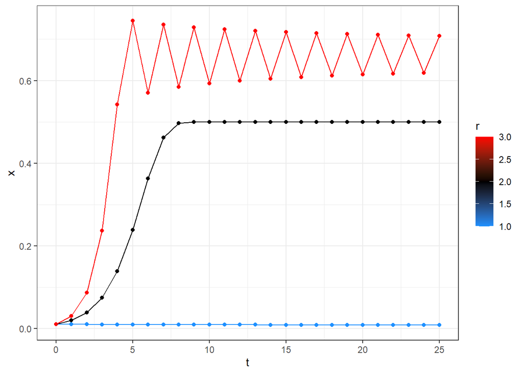

```r
gg = ggplot(
    all3trajectories,  ## pull from all 3 trajectories
    aes(x=t, y=x, group=r, color=r)
) + geom_point() + geom_line()
gg = gg + scale_color_gradientn(colors=c("dodgerblue", "black", "red"))
print(gg)
```

For $r \leq 1$, the trajectories just die off toward 0; this isn’t so surprising since our nontrivial steady state $x_{\text{*}} = \frac{r-1}{r} \leq 0$ when $r \leq 1$.

But what about $r=3$? In this case the trajectory looks almost periodic, though if you follow it long enough the amplitude of the fluctuations shrinks and the trajectory ultimately settles down to the stable value $x_{\text{*}}$.

Things get more interesting for $r > 3$:

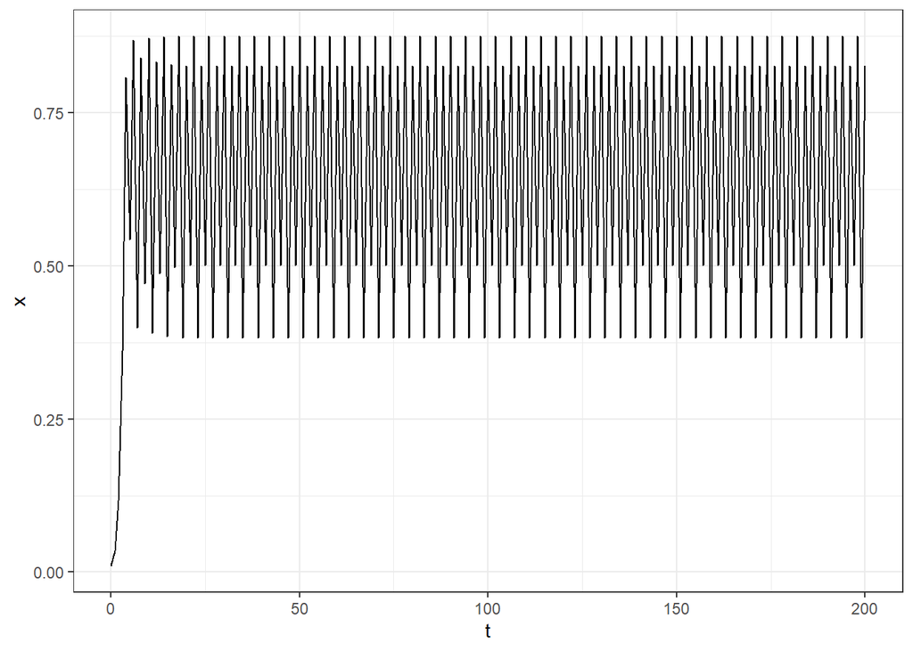

```r
traj_r3p5 = logisticMapTrajectory(r=3.5, x0=0.01, tmax=200)
ggplot(traj_r3p5, aes(x=t, y=x)) + geom_line()
```

Here we see a trajectory which, after an initial transient period, settles into periodic behavior with a period of 4 time units. For reasons which will become apparent shortly, let’s chop off the initial transient:

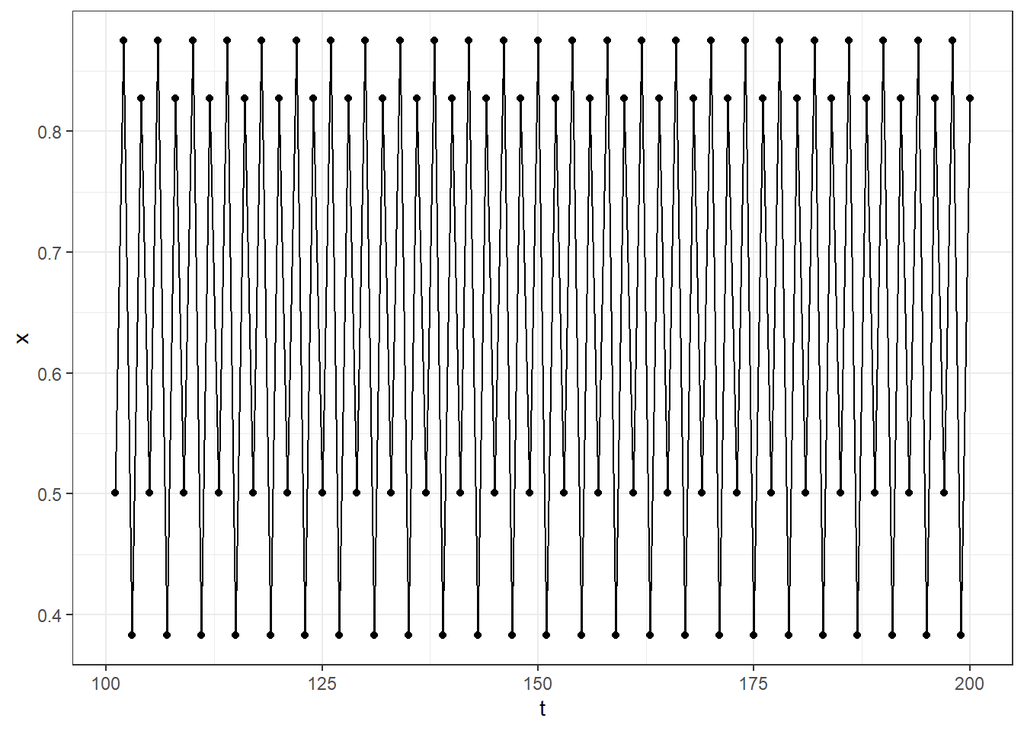

```r
traj_r3p5_last100 = traj_r3p5[traj_r3p5$t > 100, ]
 ## - line above uses logical indexing to keep only rows of
 ##   traj_r3p5 for which t-column has value > 100
 ## - all columns (t, x, and r) are retained b/c nothing put
 ##   between the comma and end-square-bracket
ggplot(traj_r3p5_last100, aes(x=t, y=x)) + geom_point() + geom_line()
```

If we’re only interested in this long-term behavior, we might collapse the whole trajectory by plotting the growth rate parameter $r$ on the $x$-axis instead of the time $t$ and omitting the lines connecting the points:

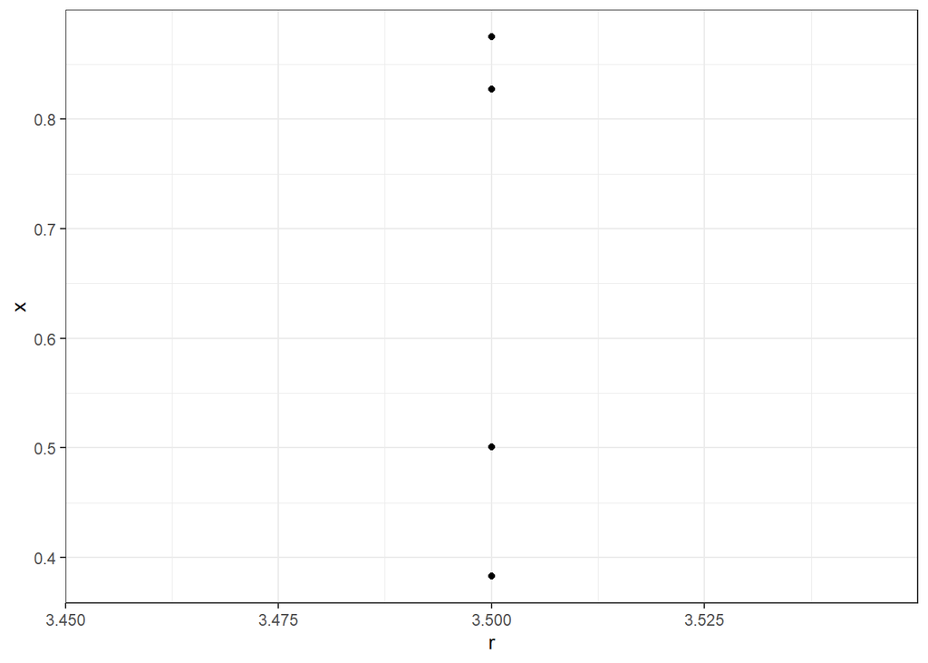

```r
ggplot(traj_r3p5_last100, aes(x=r, y=x)) + geom_point()
```

Keep in mind that there are 100 points in the plot above, but that since they take only 4 distinct values, and since we have removed any information about time $t$ from the plot, they get plotted on top of each other.

We can keep at least a minimal amount of information of the order in which the points appear by keeping track of whether we’re on an even or odd time point:

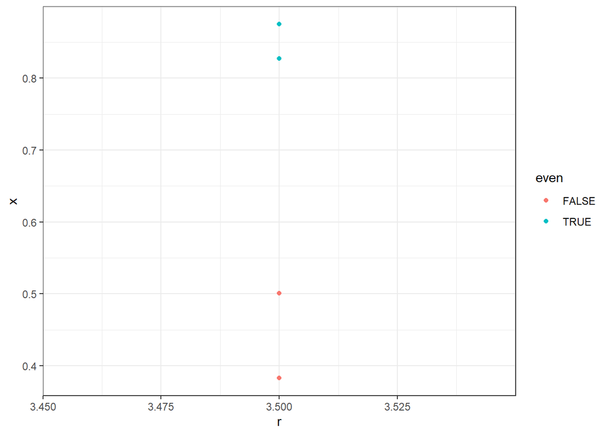

```r
timeIsEven = (traj_r3p5_last100$t %% 2 == 0)
 ## %% operator returns remainder upon dividing by right-hand-side
 ## even numbers are those with 0 remainder when dividing by 2
traj_r3p5_last100$even = timeIsEven
 ## now have column with value TRUE for even t and FALSE for odd t
 ## in data.frame traj_r3p5_last100
ggplot(traj_r3p5_last100, aes(x=r, y=x, color=even)) + geom_point()
```

This shows us that the period four trajectory bounces back and forth between higher values (at even times when starting from $x_0=0.01$) and lower values (at odd times), though the height of the higher values (and the depth of the lower values) varies from one period to the next!

That lonely $x$-axis suggests we should include some other values of $r$ as well: let’s do that…

```r
lotsOfTrajectories = list()  ## start with empty list
for (r in seq(from=0, to=4, by=0.01)) {
     ## seq function creates vector of values ranging from
     ## the 'from' value to the 'to' value in steps of the 'by' value
    lotsOfTrajectories[[length(lotsOfTrajectories)+1]] =
            logisticMapTrajectory(r, x0=0.01, tmax=200)
     ## note lack of anything to right of '=' sign two lines
     ## above tells R to look at next line for value to assign
}
```

Now we have long list of `data.frame`s we’d like to plot together. We used `rbind` to do this with 3 trajectories before, but that required specifying each `data.frame` as a separate argument to `rbind`. Don’t want to write a function call to `rbind` by typing out hundreds of arguments! Luckily there’s a way to to tell R to call a function with a whole `list` of arguments:

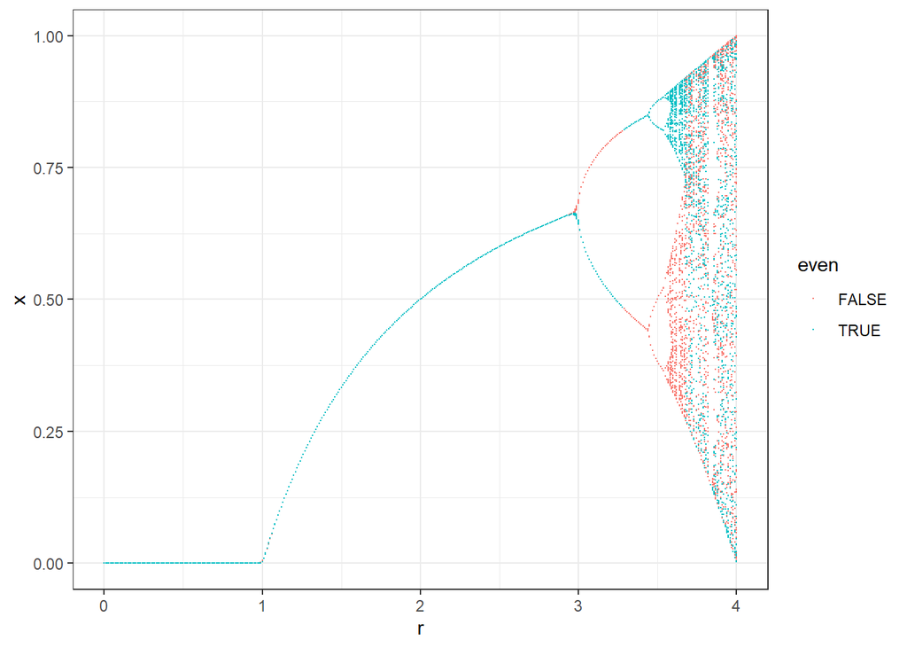

```r
rboundTrajectories = do.call(rbind, lotsOfTrajectories)
 ## do.call says to call the function specified by first argument
 ## - rbind in this case
 ## with a provided list of arguments
 ## - lotsOfTrajectories in this case
 ## now rboundTrajectories is single data.frame containing
 ## all of the trajectories
 ## - perfect for ggplot!
rboundTrajectories$even = (rboundTrajectories$t %% 2 == 0)
ggplot(
    rboundTrajectories[rboundTrajectories$t > 100, ],
    aes(x=r, y=x, color=even)
) + geom_point(size=0.1, shape=16)  ## shape=16 allows small points
```

Now we can see how the logistic map trajectories behave over a wide range of growth rates $r$ ([@may1976simple]): - $r \leq 1$ : population dies away - $1 < r \leq 3$ : population ultimately stabilizes at $x_{\text{*}}$ - $3 < r < 1+\sqrt{6}$ : oscillation with period 2 - $1+\sqrt{6} < r < 3.54409\ldots$ : oscillations with period 4 - $3.54409\ldots < r < 3.56995\ldots$ : period-doubling cascade - $3.56995\ldots < r \leq 4$ : chaos!

### Deterministic chaos

Both the geometric growth model and the logistic map are examples of *dynamical models*: models which describe the evolution of the state of a system over the course of time. Moreover, both of these models provide a rule which, in principle, allows one to determine exactly the state of the system at all future times given knowledge of the current system state. Such systems are referred to as *deterministic* systems (and can be contrasted with so-called *stochastic* systems, in which there is a random component to the rules for evolving the system forward in time).

Deterministic dynamical systems have been heavily used in scientific modeling for a long time now, especially since Newton showed that a few simple physical laws can be used to derive deterministic models simultaneously leading to highly accurate predictions of both terrestrial and celestial phenomena. The ongoing success of these models over the following century, and then of similarly constructed deterministic differential equation models of electromagnetic fields, led to a widespread belief that deterministic modeling would ultimately allow for the prediction of the course of virtually all of nature’s operations.

However, starting in the late 19th century, certain limitations in this scientific program started to appear. While strictly speaking still deterministic, some differential equation models were found to exhibit “sensitivity to initial conditions” (colloquially known as the “butterfly effect”): Any small change to the state of the system at time $t$ will become exponentially magnified as time moves forward ([@strogatz2015nonlinear]). Thus *any* imprecision in the measurement of the current state of such a system will render predictions in the relatively near future subject to very great uncertainty. This is the main ingredient in what is known as *deterministic chaos*.

In section 2.1.2 I indicated that the logistic map model with $r$ at or just below 4 it will exhibit chaotic behavior. We can demonstrate this by considering three different $r=4$ logistic map trajectories starting from the very nearby initial conditions $x_0 {0.0099, 0.01, 0.0101}$:

```r
r4trajectories = list()
for (initialCondition in seq(from=0.0099, to=0.0101, by=0.0001)) {
    r4trajectories[[length(r4trajectories)+1]] =
            logisticMapTrajectory(r=4, x0=initialCondition, tmax=25)
     ## add column ic indicating what the initial condition was in
     ## so that we can keep track of which simulation was which
     ## after we rbind all of these trajectories together
     ## into one data.frame:
    r4trajectories[[length(r4trajectories)]]$ic = initialCondition
     ## (since initialCondition is just a single number, the column
     ##  ic will just end up being 201 copies of this same number)
}
 ## use do.call with rbind to reformat list into data.frame again;
 ## this time we'll just redefine r4trajectories itself:
r4trajectories = do.call(rbind, r4trajectories)
```

Having run the three simulations starting from the different initial conditions 0.0099, 0.01, and 0.0101 and packaged them up into a single `data.frame` object, we can use `ggplot` to visualize the three resulting trajectories:

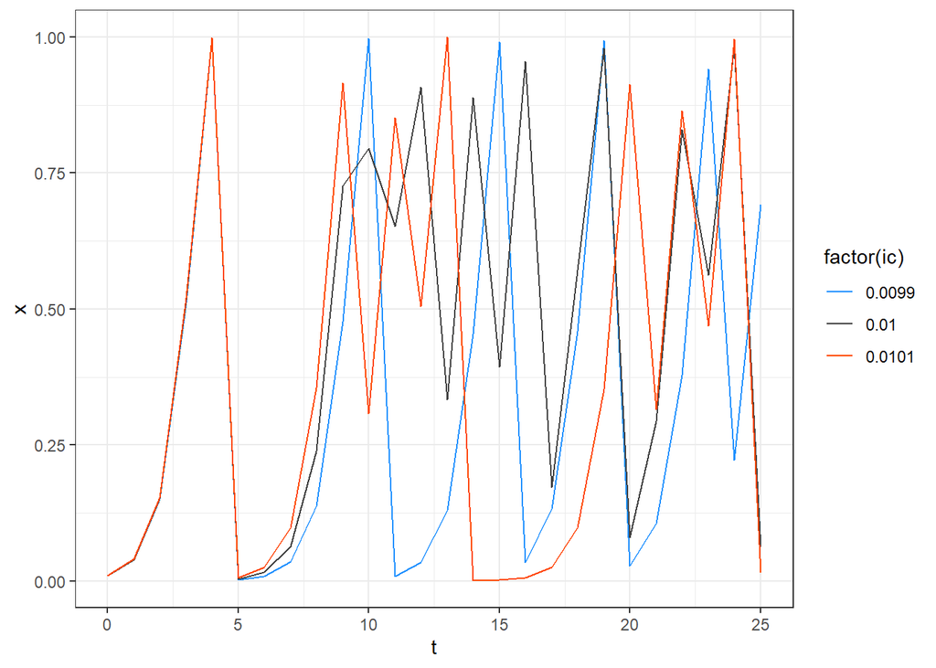

```r
gg = ggplot(r4trajectories,
            aes(x = t,
                y = x,
                group = ic,  ## group aesthetic tells geom_line
                             ## to treat rows of r4trajectories
                             ## with different ic values as part
                             ## of separate lines
                 ## now set color aesthetic to categorical,
                 ## or factor, version of ic column
                 ## (easier to deal with coloring small number of
                 ##  values in ggplot if they are treated as discrete
                 ##  values instead of continuous numbers):
                color = factor(ic)))
gg = gg + geom_line()
gg = gg + scale_color_manual(
    values = c("dodgerblue", "gray25", "orangered")
)
print(gg)
```

From the plot we can clearly see that an error in the 4th decimal in the estimation of the initial state of the logistic map trajectory leads to totally incorrect prediction of what the trajectory looks like after as few as 10 iterations!

This certainly doesn’t mean that there is nothing to be learned from modeling chaotic systems. For one thing, you can see that the immediate future is still predictable even if the present is subject to the inevitable measurement error: for the first few time steps the blue, gray, and orange trajectories move together just as one would expect given the similarity in their initial states. But beyond this, even if attempts to predict all of the local details of a particular trajectory of a chaotic system may be doomed, there are larger scale properties that may be understood.

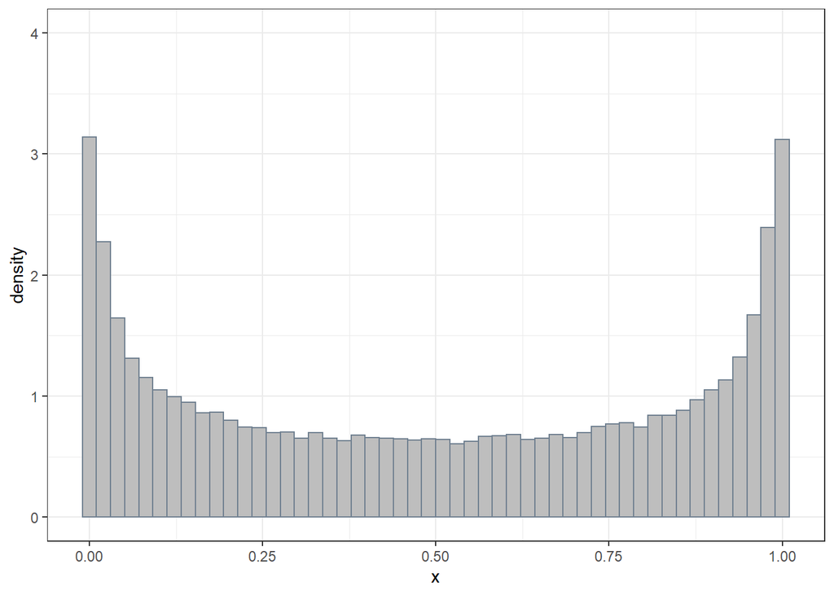

```r
r4trajLong = logisticMapTrajectory(r=4, x0=0.01, tmax=50000)
 ## use ggplot to histogram this data:
gg = ggplot(r4trajLong)
gg = gg + geom_histogram(
     ## can specify aes (aesthetic) mappings as argument to individual
     ## geoms as well as in the initial ggplot function call:
    aes(x=x, y=..density..),  ## y=..density.. here says to scale y-axis
                              ## so that total *area* of all bars together
                              ## sums to 1, like a probability distribution
    bins = 50,
    fill = "gray",        ## inner fill color of the histogram bars
    color = "slategray"   ## the outline color of the bars
)
 ## set limits of y-axis to between 0 and 4:
gg = gg + ylim(0, 4)
print(gg)
```

Aside from a few exceptional cases like the trajectory $x(t)=0$ for all $t$, almost all trajectories of the $r=4$ version of the logistic map system will result in this exact same distribution of time spent visiting various different $x$ values over the long haul! The functional form of this distribution for $r=4$ turns out to be $\frac{1}{\pi \sqrt{x(1-x)}}$ ([@berliner1992statistics]), which is the probability density function associated with the arcsin distribution (so-named because if has *cumulative* distribution function proportional to arcsin, the functional inverse of sin):

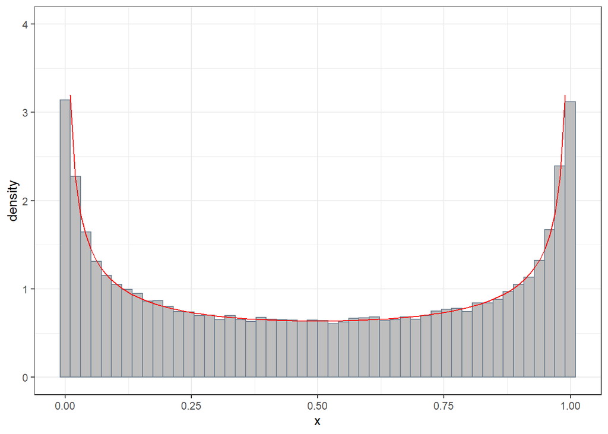

```r
## install.packages("VaRES")  ## uncomment and run if necessary
library(VaRES)  ## has arcsine distribution functions
                ## (we want darcsine,
                ##  the probability *d*ensity function for *arcsin*)
 ## use stat_function to add the plot of a function to a ggplot object:
gg = gg + stat_function(fun=function(x){1/(pi*sqrt(x*(1-x)))}, color="red")
print(gg)
```

While this is not necessarily the only—or perhaps even most important—reason probabilistic modeling plays as important a role as it does in biological modeling, the fact that chaotic behavior is quite common in the type of models which seem most plausible for many biological phenomena is worth noting. It would seem to suggest that if we want to make quantitative predictions regarding the the response of such systems to experimental stimuli, we may often be limited to probabilistic statements.